# MLB eligible population; Supplement to Comparing baseball players across eras via the novel Full House Model

Shen Yan, Adrian Burgos Jr., Christopher Kinson, and Daniel J. Eck

In this document we estimate the MLB eligible population factoring in the changing levels of interest in the game. This document will frequently reference [Baseball Reference](https://www.baseball-reference.com/), the [US Census](https://www.census.gov/), [Statistics Canada](https://www12.statcan.gc.ca/census-recensement/index-eng.cfm), [Gallup survey data](https://news.gallup.com/poll/4735/sports.aspx), and [Wikipedia](https://en.wikipedia.org/wiki/Main_Page). This document will closely follow the calculations made in and . However, we will take a more exacting look at the MLB eligible population and historical baseball inference.

In this document the eligible MLB population will follow [Baseball Reference’s page](https://www.baseball-reference.com/bio/) listing a player’s birthplace. Most countries that have produced two or more players will be added to the eligible MLB population. The countries that will form our eligible MLB population will be Aruba, Australia, Bahamas, Brazil, Canada, Colombia, Cuba, Curaçao, Dominican Republic, Jamaica, Japan, Mexico, Nicaragua, Panama, Puerto Rico, South Korea, Taiwan, the United States, the United States Virgin Islands, and Venezuela.

Latin American countries’ populations will often be added four years before their first MLB player reached the MLB unless otherwise noted. This is to reflect the interest in baseball that must precede the arrival of an MLB player. The same will not apply to Asian players. This reflects the [defacto ban](http://baseballguru.com/jalbright/analysisjalbright15.html) that was in place prior to 1994 which limited Japanese players from entering the MLB. We attempt to weigh each year by each countries’ interest in baseball using polling sources when this information is available.

We first obtain the the estimated MLB eligible population for the United States and Canada before 1960. Links to sources are commented below.

```r
years <- 1871:2021

### Canadian population before 1960
#https://www65.statcan.gc.ca/acyb02/1907/acyb02_1907001701a-eng.htm
Can1871 <- 0.16 + 0.13
Can1881 <- 0.21 + 0.17
Can1891 <- 0.24 + 0.19
Can1901 <- 0.26 + 0.22

#https://www65.statcan.gc.ca/acyb02/1947/acyb02_19470113009-eng.htm
CanM1871 <- 1.87
CanM1881 <- 2.19
CanM1891 <- 2.16
CanM1901 <- 2.75

# estimated proportion of males aged 20-30 with respect to males of
# all ages
propCan2030 <- (Can1871 + Can1881 + Can1891 + Can1901) /
  (CanM1871 + CanM1881 + CanM1891 + CanM1901)

#https://www65.statcan.gc.ca/acyb02/1947/acyb02_19470113009-eng.htm
Can1911 <- 3.82 * propCan2030
Can1921 <- 4.53 * propCan2030
Can1931 <- 5.37 * propCan2030
Can1941 <- 5.90 * propCan2030

#https://www65.statcan.gc.ca/acyb02/1967/acyb02_19670194010-eng.htm
Can1951 <- 7.09 * propCan2030

### US population before 1960
#https://www2.census.gov/library/publications/decennial/1870/vital-statistics/1870b-33.pdf
US1870 <- 1.45 + 1.52
#https://www2.census.gov/library/publications/decennial/1880/vol-01-population/1880_v1-15.pdf
US1880 <- 2.22 + 1.84
#https://www2.census.gov/library/publications/decennial/1900/volume-2/volume-2-p5.pdf
US1900 <- 2.73 + 2.37
US1890 <- mean(c(US1880,US1900))
#https://www2.census.gov/library/publications/decennial/1910/volume-1/volume-1-p6.pdf
US1910 <- 4.07 + 3.79
#https://www2.census.gov/library/publications/decennial/1920/volume-2/41084484v2ch03.pdf
US1920 <- 4.02 + 4.09
#https://www2.census.gov/library/publications/decennial/1930/population-volume-2/16440598v2ch11.pdf
US1930 <- 4.69 + 4.25
#https://www2.census.gov/library/publications/decennial/1940/population-volume-4/33973538v4p1ch1.pdf
US1940 <- 1.08 + 1.06 + 1.01 + 1.00 + 1.01 +
  1.01 + 0.99 + 0.98 + 0.97 + 0.95
#https://www2.census.gov/library/publications/decennial/1950/population-volume-2/21983999v2p1ch2.pdf
US1950 <- 5.00 + 5.30

Can <- c(Can1871, Can1881, Can1891, Can1901, Can1911, Can1921, Can1931, Can1941, Can1951)
US <- c(US1870, US1880, US1890, US1900, US1910, US1920, US1930, US1940, US1950)
datUSCan7050 <- data.frame(year = 187:195 * 10, US, Can)
```

We now provide estimates for the US and Canada populations for 1960 until the present, and we combine those estimates with the previous 1870-1950 estimates.

```r
########################################
### Load in population data
########################################
library(tidyverse)
population_data <- read.csv("population.csv", header = TRUE)[, -1] %>%
  mutate(age20 = age20 / 1e3, age25 = age25 / 1e3) %>%
    mutate(pop = age20 + age25) %>%
    select("region", "year", "pop") %>%
  filter(year >= 1950)
population_data$region <- as.factor(population_data$region)
population_data$region <- recode_factor(
    population_data$region, WORLD = "world", Canada = "Can",
    "United States of America" = "US")

foo <- population_data %>% filter(region %in% c("US", "Can")) %>%
    filter(year >= 1960)
datUSCan6010 <- spread(foo, region, pop)[, c(1,3,2)]
bar  <- rbind(datUSCan7050, datUSCan6010) %>%
    mutate(pop = US + Can) %>%
    select(year, pop)

#https://www.census.gov/programs-surveys/popest/technical-documentation/research/evaluation-estimates.html
#https://www.worldometers.info/world-population/us-population/
# US population in 2021 divided by US population in 2010
# population estimate taken October 11, 2021
bar[16, ] <- c(2021, 333474263 / 308745538  * bar[15, 2])
baz <- approx(x = bar$year, y = bar$pop, xout = years, n = length(years))
datUSCan <- data.frame(year = baz$x, pop = baz$y)
```

We now estimate baseball interest starting with [Gallup polling data](https://news.gallup.com/poll/4735/sports.aspx) on the US population’s favorite sport to watch, and we will assume the same interest levels for Canada. We shift historical interest by 13 years, so that the interest level for eligible MLB players aged 20-29 reflects when these players grew up (age 7-16).

```r
#https://news.gallup.com/poll/4735/sports.aspx
interest <- data.frame(
  year = c(1937, 1948, 1960, 1972, 1981, 1990, 1994, 1998, 2000, 2001, 2002,
                 2003, 2004, 2005, 2006, 2007, 2008, 2013, 2017) + 13,
  interest = c(0.34, 0.39, 0.34, 0.22, 0.16, 0.16, 0.18, 0.12, 0.13, 0.12, 0.12,
                    0.10, 0.10, 0.12, 0.11, 0.13, 0.10, 0.14, 0.09)
)
foo <- approx(x = interest$year, y = interest$interest, xout = 1950:2024)
dat_interest <- data.frame(year = foo$x, interest = foo$y)
```

It is important to note that the Gallup survey does not parse out football and basketball into professional and college leagues while baseball is mostly only the MLB. Active MLB fans account for [roughly 45% of the population](https://www.forbes.com/sites/maurybrown/2018/01/12/has-mlb-been-passed-by-the-nba-in-popularity-the-problems-with-the-gallup-poll/?sh=3927c49a2cd3) as of 2017.

```r
dat_interest %>% filter(year == 2010 + 13)
```

```
##   year interest
## 1 2023    0.116
```

We therefore will not allow the minimum interest in baseball to be lower than 15.5%.

```r
dat_interest$interest <- unlist(lapply(dat_interest$interest,
  function(x) max(c(x,0.155))))
```

```r
## obtain attendance data
MLBattendance <- read.csv("MLBattendance.csv") %>%
    rename(year = "Year")
MLBattendance[, 3] <- as.numeric(gsub(",", "", as.character(MLBattendance[, 3]))) / 1000
MLBattendance <- MLBattendance %>% rename(attend = "Attend.G")

## obtain Gallup interest data
#MLBinterest <- data.frame(
#  year = c(1937, 1948, 1960, 1972, 1981, 1990, 1994, 1998, 2000, 2001, 2002,
#                2003, 2004, 2005, 2006, 2007, 2008, 2013, 2017),
#  interest = c(0.34, 0.39, 0.34, 0.22, 0.16, 0.16, 0.18, 0.12, 0.13, 0.12, 0.12,
#                   0.10, 0.10, 0.12, 0.11, 0.13, 0.10, 0.14, 0.09) * multiple
#)

MLBinterest <- data.frame(
  year = c(1937, 1948, 1960, 1972, 1981, 1990, 1994, 1998, 2000, 2001, 2002,
                 2003, 2004, 2005, 2006, 2007, 2008, 2013, 2017),
  interest = c(0.34, 0.39, 0.34, 0.22, 0.16, 0.16, 0.18, 0.12, 0.13, 0.12, 0.12,
                    0.10, 0.10, 0.12, 0.11, 0.13, 0.10, 0.14, 0.09)
)
MLBinterest$interest <- unlist(lapply(MLBinterest$interest,
  function(x) max(c(x,0.155))))


## interpolate interest and combine with attendance
foo2 <- approx(x = MLBinterest$year, y = MLBinterest$interest, xout = 1937:2017)
dat_MLBinterest <- data.frame(year = foo2$x, interest = foo2$y)
bar <- merge(dat_MLBinterest, datUSCan) %>% mutate(pop = pop * interest)
attend <- (MLBattendance %>% filter(year >= 1937, year <= 2017) %>%
                        select(attend))
attend <- as.numeric(unlist(attend))
bar$attend <- attend
dat <- bar %>% filter(year < 1994) %>% mutate(year = year / 1000)
```

We fit a regression model with interest weighted MLB population as the response and quadratic terms for attendance and year.

```r
## fit is good
m1 <- lm(pop ~ attend + I(attend^2) +
                 year + I(year^2), data = dat)
summary(m1)
```

```
##
## Call:
## lm(formula = pop ~ attend + I(attend^2) + year + I(year^2), data = dat)
##
## Residuals:
##      Min       1Q   Median       3Q      Max
## -0.27150 -0.07156  0.00622  0.04861  0.32048
##
## Coefficients:
##               Estimate Std. Error t value Pr(>|t|)
## (Intercept) -1.841e+03  5.093e+02  -3.614 0.000680 ***
## attend       2.633e-02  4.763e-02   0.553 0.582669
## I(attend^2)  6.132e-04  9.076e-04   0.676 0.502279
## year         1.865e+03  5.219e+02   3.573 0.000771 ***
## I(year^2)   -4.715e+02  1.335e+02  -3.530 0.000879 ***
## ---
## Signif. codes:  0 '***' 0.001 '**' 0.01 '*' 0.05 '.' 0.1 ' ' 1
##
## Residual standard error: 0.1184 on 52 degrees of freedom
## Multiple R-squared:  0.8184, Adjusted R-squared:  0.8044
## F-statistic: 58.57 on 4 and 52 DF,  p-value: < 2.2e-16
```

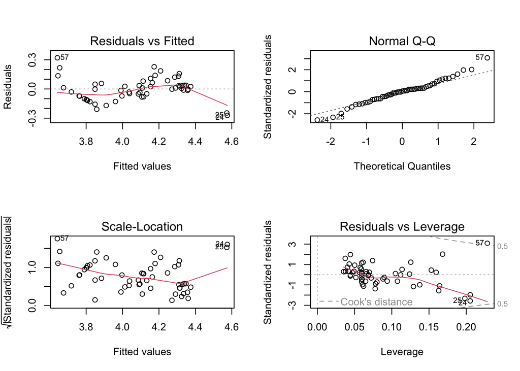

```r
par(mfrow = c(2,2))
plot(m1)
```

We now predict interest weighted MLB population for years 1920 to 1937 and compute interest.

```r
baz <- data.frame(year = 1920:1936 / 1000,
                                    attend = MLBattendance %>%
                                        filter(year >= 1920, year <= 1936) %>%
                                        select(attend))
dat_pop2036 <- data.frame(year = 1920:1936,
  pop = predict(m1, newdata = baz),
  tot = as.numeric(unlist(datUSCan %>% filter(year %in% 1920:1936) %>%
    select(pop))))
interest2036 <- dat_pop2036[, 2] / dat_pop2036[, 3]
interest2036
```

```
##  [1] 0.2170553 0.2186101 0.2210116 0.2217107 0.2273008 0.2345829 0.2424344
##  [8] 0.2434432 0.2443628 0.2489684 0.2508728 0.2515523 0.2529215 0.2514416
## [15] 0.2528053 0.2533605 0.2554885
```

We now shift interest as before and add it to our data frame on interest.

```r
dat_interest <- rbind(data.frame(year = 1933:1949, interest = interest2036),
                                            dat_interest)
```

Prior to Babe Ruth and the radio attendance was lower (World War 1 and the Spanish flu were also occurring during this time). We see that the average attendance from 1917 to 1919 is about 60% of the average attendance from 1920 to 1922

```r
perc <- mean((MLBattendance %>% filter(year %in% 1917:1919))$attend) /
    mean((MLBattendance %>% filter(year %in% 1920:1922))$attend)
perc
```

```
## [1] 0.6069719
```

So we will assume that 1917 (shifted from 1930) has 60% of the interest as the average interest from 1920 to 1922, and we will linearly interpolate the in between values.

```r
interest1720 <- approx(x = c(1930,1933),
             y = c(mean((dat_interest %>% filter(year %in% 1933:1935))$interest) * perc,
                        0.2615039), xout = 1930:1932)
dat_interest <- rbind(data.frame(year = 1930:1932, interest = interest1720$y),
                                            dat_interest)
```

There is not much concrete information for estimating baseball interest prior to what have estimated so far. stated that at the onset of the 20th century, participation in MLB was confined to White Americans, originating primarily in the Northeastern states. We will suppose that baseball interest was 12% in 1871 and we will interpolate every value between 1871 and 1916 (shifted from 1929).

```r
interest7116 <- approx(x = c(1871,1929),
             y = c(0.12, 0.1634787), xout = 1871:1929)
dat_interest <- rbind(data.frame(year = 1871:1929, interest = interest7116$y),
                                            dat_interest)
```

We now obtain the eligible MLB population for US and Canada after factoring in the changing interest in baseball.

```r
datUSCan$pop <- datUSCan$pop * dat_interest$interest[1:nrow(datUSCan)]
head(datUSCan)
```

```
##   year       pop
## 1 1871 0.4053600
## 2 1872 0.4221407
## 3 1873 0.4390983
## 4 1874 0.4562329
## 5 1875 0.4735443
## 6 1876 0.4910327
```

```r
tail(datUSCan)
```

```
##     year      pop
## 146 2016 4.020099
## 147 2017 4.048145
## 148 2018 4.076191
## 149 2019 4.104237
## 150 2020 4.132284
## 151 2021 4.160330
```

### Other countries

#### The early Latin American countries

##### Cuba

[Cuba](https://www.baseball-reference.com/bio/Cuba_born.shtml) continued to provide a steady stream of MLB talent after integration. Cubans have historically been among the most fervent of baseball fans, and have long been demanding of high caliber play . Moreover, the prospect of beating Americans at their own game has long held special appeal to Cuba’s leaders . Baseball is the most popular sport in Cuba and 62% [play it](https://en.wikipedia.org/wiki/Sport_in_Cuba), and baseball is the official sport of Cuba. We will use the figure of 62% as a measure of Cuba’s historic interest in baseball.

```r
foo <- population_data %>% filter(region %in% c("Cuba")) %>%
    mutate(pop = pop * 0.62)
#https://www.worldometers.info/world-population/cuba-population/
# Cuban population in 2021 divided by Cuba population in 2010
# population estimate taken October 11, 2021
foo[8, 1] <- foo[7, 1]; foo[8, 2:3] <- c(2021, foo[7,3] * 11.317806/11.23)
bar <- spread(foo, region, pop)
baz <- approx(x = bar$year, y = bar$Cuba, xout = 1950:2021, n = 70)
datCuba <- data.frame(year = baz$x, pop = baz$y)
head(datCuba)
```

```
##   year       pop
## 1 1950 0.2971617
## 2 1951 0.3044215
## 3 1952 0.3116814
## 4 1953 0.3189413
## 5 1954 0.3262012
## 6 1955 0.3334611
```

```r
tail(datCuba)
```

```
##    year       pop
## 67 2016 0.4900839
## 68 2017 0.4904308
## 69 2018 0.4907776
## 70 2019 0.4911245
## 71 2020 0.4914714
## 72 2021 0.4918183
```

This approximation is comparable to previous estimates. By 1977 Ron Fimrite reported that: An estimated 493,000 Cubans out of a total population of about nine million play some form of organized baseball . Our estimate of the eligible MLB population (aged 20-29 males) is

```r
(datCuba %>% filter(year == 1977) %>% select(pop)) * 1e6
```

```
##        pop
## 1 469380.2
```

Of course these estimates are for slightly different quantities. We target interest among aged 20-29 males. While Fimrite reported totals for overall participation in organized baseball, either in school or in the complicated system established by the government’s Cuban Baseball Federation . Both are estimates, it is encouraging to see that our estimate is slightly lower and is close to Firmrite’s estimate. Also, we desire to weight by interest. So it is likely that our estimate underestimates overall interest.

##### Dominican Republic

[The Dominican Republic](https://www.baseball-reference.com/bio/Dominican-Republic_born.shtml) continued to provide a steady stream of MLB talent after integration. A figure quantifying baseball interest in the Dominican Republic is not easily obtainable. Considering that 62% of Cubans play baseball and that the Dominican Republic produces more MLB talent, we will place the interest level for the Dominican Republic at 85%.

```r
population_data$region <- recode_factor(
    population_data$region, "Dominican Republic" = "DR")
foo <- population_data %>% filter(region %in% c("DR")) %>%
    mutate(pop = pop * 0.85)
#https://www.worldometers.info/world-population/dominican-republic-population/
# DR population in 2021 divided by DR population in 2010
# population estimate taken October 11, 2021
foo[8, 1] <- foo[7, 1]; foo[8, 2:3] <- c(2021, foo[7,3] * 10.986358 / 9.7)
bar <- spread(foo, region, pop)
baz <- approx(x = bar$year, y = bar$DR, xout = 1950:2021, n = 70)
datDR <- data.frame(year = baz$x, pop = baz$y)
head(datDR)
```

```
##   year       pop
## 1 1950 0.1619904
## 2 1951 0.1674376
## 3 1952 0.1728847
## 4 1953 0.1783319
## 5 1954 0.1837790
## 6 1955 0.1892261
```

```r
tail(datDR)
```

```
##    year       pop
## 67 2016 0.7791490
## 68 2017 0.7879087
## 69 2018 0.7966684
## 70 2019 0.8054280
## 71 2020 0.8141877
## 72 2021 0.8229474
```

##### Panama

[Panama](https://www.baseball-reference.com/bio/Panama_born.shtml) continued to provide a steady stream of MLB talent after integration with a pronounced blip between 1979 and 1986. We will reduce the eligible MLB population by 50% over that span. A figure quantifying baseball interest in Panama is not easily obtainable. Considering that 62% of Cubans play baseball and that Panama produces comparable MLB talent given the differences in population, we will place the interest level for Panama at 62%.

```r
population_data$region <- recode_factor(
    population_data$region, "Panama" = "Pan")
foo <- population_data %>% filter(region %in% c("Pan")) %>%
    mutate(pop = pop * 0.62)
#https://www.worldometers.info/world-population/panama-population/
# Pan population in 2021 divided by Pan population in 2010
# population estimate taken October 11, 2021
foo[8, 1] <- foo[7, 1]; foo[8, 2:3] <- c(2021, foo[7,3] * 4.401139 / 3.64)
bar <- spread(foo, region, pop)
baz <- approx(x = bar$year, y = bar$Pan, xout = 1950:2021, n = 70)
datPan <- data.frame(year = baz$x, pop = baz$y)
datPan[datPan$year %in% 1979:1986, ]$pop <-
    0.5 * datPan[datPan$year %in% 1979:1986, ]$pop
head(datPan)
```

```
##   year        pop
## 1 1950 0.04283766
## 2 1951 0.04378006
## 3 1952 0.04472246
## 4 1953 0.04566486
## 5 1954 0.04660726
## 6 1955 0.04754966
```

```r
tail(datPan)
```

```
##    year       pop
## 67 2016 0.2034357
## 68 2017 0.2069069
## 69 2018 0.2103782
## 70 2019 0.2138495
## 71 2020 0.2173208
## 72 2021 0.2207921
```

##### Puerto Rico

[Puerto Rico](https://www.baseball-reference.com/bio/Puerto-Rico_born.shtml) continued to provide a steady stream of MLB talent after integration. A figure quantifying baseball interest in Puerto Rico is not easily obtainable. Considering that 62% of Cubans play baseball and that Puerto Rico produces comparable MLB talent with less people, we will place the interest level for Puerto Rico at 85%.

```r
population_data$region <- recode_factor(
    population_data$region, "Puerto Rico" = "PR")
foo <- population_data %>% filter(region %in% c("PR")) %>%
    mutate(pop = pop * 0.85)
#https://www.worldometers.info/world-population/panama-population/
# PR population in 2021 divided by PR population in 2010
# population estimate taken October 11, 2021
foo[8, 1] <- foo[7, 1]; foo[8, 2:3] <- c(2021, foo[7,3] * 2.765747 / 3.7)
bar <- spread(foo, region, pop)
baz <- approx(x = bar$year, y = bar$PR, xout = 1950:2021, n = 70)
datPR <- data.frame(year = baz$x, pop = baz$y)
head(datPR)
```

```
##   year       pop
## 1 1950 0.1420350
## 2 1951 0.1397568
## 3 1952 0.1374787
## 4 1953 0.1352005
## 5 1954 0.1329223
## 6 1955 0.1306442
```

```r
tail(datPR)
```

```
##    year       pop
## 67 2016 0.2025148
## 68 2017 0.1971237
## 69 2018 0.1917325
## 70 2019 0.1863413
## 71 2020 0.1809502
## 72 2021 0.1755590
```

We will extrapolate the tallies of Cuba, Dominican Republic, Puerto Rico, and Panama to 1948, the first complete season of post-integration baseball. We will also combine these tallies to those computed for the US and Canada.

```r
MLBpop <- datUSCan
MLBpop[datUSCan$year %in% 1948:2021, ]$pop <-
    datUSCan[datUSCan$year %in% 1948:2021, ]$pop +
    c(0.62, 0.63, datCuba$pop + datDR$pop + datPan$pop + datPR$pop)
```

#### Additional Latin American countries

##### Aruba

[Aruba](https://www.baseball-reference.com/bio/Aruba_born.shtml) has recently produced a steady stream MLB players beginning in 1996. Baseball is [one of the most popular sports](https://en.wikipedia.org/wiki/Sports_in_Aruba) on the island, with a number of Aruban citizens having gone to the United States to play professionally. Considering that 62% of Cubans play baseball and that Aruba produces comparable MLB talent given the differences in population, we will place the interest level for Panama at 62%. We will add Aruba to the eligible MLB population starting in 1992, four years before their first player made the MLB.

```r
foo <- population_data %>% filter(region %in% c("Aruba")) %>%
    mutate(pop = pop * 0.62)
#https://www.worldometers.info/world-population/aruba-population/
# Aruba population in 2021 divided by Aruba population in 2010
# population estimate taken October 11, 2021
foo[8, 1] <- foo[7, 1]; foo[8, 2:3] <- c(2021, foo[7,3] * 1073.43 / 1017)
bar <- spread(foo, region, pop)
baz <- approx(x = bar$year, y = bar$Aruba, xout = 1992:2021)
datAruba <- data.frame(year = baz$x, pop = baz$y)
head(datAruba)
```

```
##   year         pop
## 1 1992 0.003143028
## 2 1993 0.003172292
## 3 1994 0.003201556
## 4 1995 0.003230820
## 5 1996 0.003260084
## 6 1997 0.003289348
```

```r
tail(datAruba)
```

```
##    year         pop
## 25 2016 0.004209459
## 26 2017 0.004230069
## 27 2018 0.004250678
## 28 2019 0.004271288
## 29 2020 0.004291898
## 30 2021 0.004312508
```

We add this population to the overall tally of the eligible MLB population.

```r
MLBpop[MLBpop$year >= 1992, ]$pop <-
    MLBpop[MLBpop$year >= 1992, ]$pop + datAruba$pop
```

##### Bahamas

```r
population_data$region <- recode_factor(
    population_data$region, "Bahamas" = "BA")
foo <- population_data %>% filter(region %in% c("BA")) %>%
    mutate(pop = pop * 0.20)
#https://www.worldometers.info/world-population/bahamas-population/
# Bahamas population in 2021 divided by Bahamas population in 2010
# population estimate taken October 11, 2021
foo[8, 1] <- foo[7, 1]; foo[8, 2:3] <- c(2021, foo[7,3] * 398027 / 354942)
foo <- foo %>% arrange(year)
bar <- spread(foo, region, pop)
baz <- approx(x = bar$year, y = bar$BA, rule = 2,
                            xout = 1930:2021, n = length(1930:2021))
datBA <- data.frame(year = baz$x, pop = baz$y)
head(datBA)
```

```
##   year       pop
## 1 1930 0.0011458
## 2 1931 0.0011458
## 3 1932 0.0011458
## 4 1933 0.0011458
## 5 1934 0.0011458
## 6 1935 0.0011458
```

```r
tail(datBA)
```

```
##    year         pop
## 87 2016 0.006266119
## 88 2017 0.006330973
## 89 2018 0.006395826
## 90 2019 0.006460679
## 91 2020 0.006525532
## 92 2021 0.006590386
```

We add this population to the overall tally of the eligible MLB population.

```r
MLBpop[MLBpop$year >= 1930, ]$pop <-
    MLBpop[MLBpop$year >= 1930, ]$pop + datBA$pop
```

##### Brazil

[Brazil](https://www.baseball-reference.com/bio/Brazil_born.shtml) has recently produced a handful of MLB players beginning in 2012. That being said, baseball is [not very popular in Brazil](https://en.wikipedia.org/wiki/Sport_in_Brazil). We will place the interest level for Brazil at 2%.

```r
population_data$region <- recode_factor(
    population_data$region, "Brazil" = "BR")
foo <- population_data %>% filter(region %in% c("BR")) %>%
    mutate(pop = pop * 0.02)
#https://www.worldometers.info/world-population/brazil-population/
# Brazil population in 2021 divided by Brazil population in 2010
# population estimate taken October 11, 2021
foo[8, 1] <- foo[7, 1]; foo[8, 2:3] <- c(2021, foo[7,3] * 214.483151 / 195.7)
bar <- spread(foo, region, pop)
baz <- approx(x = bar$year, y = bar$BR, xout = 2012:2021)
datBR <- data.frame(year = baz$x, pop = baz$y)
head(datBR)
```

```
##   year       pop
## 1 2012 0.3546074
## 2 2013 0.3576484
## 3 2014 0.3606894
## 4 2015 0.3637304
## 5 2016 0.3667714
## 6 2017 0.3698125
```

```r
tail(datBR)
```

```
##    year       pop
## 5  2016 0.3667714
## 6  2017 0.3698125
## 7  2018 0.3728535
## 8  2019 0.3758945
## 9  2020 0.3789355
## 10 2021 0.3819765
```

We add this population to the overall tally of the eligible MLB population.

```r
MLBpop[MLBpop$year >= 2012, ]$pop <-
    MLBpop[MLBpop$year >= 2012, ]$pop + datBR$pop
```

##### Colombia

An influx of Colombian players began in the [mid-1990s](https://www.baseball-reference.com/bio/Colombia_born.shtml). We include Colombia into the eligible MLB talent pool starting in 1992, four years before the first player of this influx, Edgar Renteria, entered the MLB. Before 1992 Colombia produced only two MLB players. Baseball is not a major sport in Colombia. Although a figure quantifying baseball interest in Colombia is not easily obtainable, we will place interest at 5%.

```r
population_data$region <- recode_factor(
    population_data$region, "Colombia" = "Col")
foo <- population_data %>% filter(region %in% c("Col")) %>%
    mutate(pop = pop * 0.05)
#https://www.worldometers.info/world-population/colombia-population/
# Colombia population in 2021 divided by Colombia population in 2010
# population estimate taken October 11, 2021
foo[8, 1] <- foo[7, 1]; foo[8, 2:3] <- c(2021, foo[7,3] * 51.573067 / 45.22)
bar <- spread(foo, region, pop)
baz <- approx(x = bar$year, y = bar$Col, xout = 1992:2021)
datCol <- data.frame(year = baz$x, pop = baz$y)
head(datCol)
```

```
##   year       pop
## 1 1992 0.1633703
## 2 1993 0.1645845
## 3 1994 0.1657986
## 4 1995 0.1670128
## 5 1996 0.1682270
## 6 1997 0.1694411
```

```r
tail(datCol)
```

```
##    year       pop
## 25 2016 0.2146239
## 26 2017 0.2171700
## 27 2018 0.2197161
## 28 2019 0.2222622
## 29 2020 0.2248082
## 30 2021 0.2273543
```

We add this population to the overall tally of the eligible MLB population.

```r
MLBpop[MLBpop$year >= 1992, ]$pop <-
    MLBpop[MLBpop$year >= 1992, ]$pop + datCol$pop
```

##### Curaçao

Per Baseball Reference and [MLB.com](https://www.mlb.com/news/a-small-island-looks-at-curacao-baseball-stars), fifteen Curaçao natives have played in the Major Leagues making for a rate of roughly one per every 10,000 residents that far surpasses the yield of any other country in the world. We are going to place baseball interest in Curaçao at 100% (probably should be higher!). We will add Curaçao’s tally to the overall population beginning in 1985, four years before the [first player](https://www.baseball-reference.com/bio/Curacao_born.shtml) from Curaçao joined the MLB. Roughly 6% of Curaçao’s population are males aged 20-29 according to their [2011 Census](https://www.cbs.cw/_flysystem/media/demography-of-curacao-census-2011_0.pdf).

```r
foo <- approx(x = c(1981, 1992, 2001, 2011, 2021),
                            y = c(.148, .144, .131, .151, .165) * .06, xout = 1985:2021)
```

We add this population to the overall tally of the eligible MLB population.

```r
MLBpop[MLBpop$year >= 1985, ]$pop <-
    MLBpop[MLBpop$year >= 1985, ]$pop + foo$y
```

##### Jamaica

[Jamaica](https://www.baseball-reference.com/bio/Aruba_born.shtml) has produced a handful of MLB players beginning recently with Chili Davis in 1981. Baseball is a new, [non-traditional sport](https://www.sportanddev.org/en/article/news/north-america-baseball-jamaica) in Jamaica. We will add Jamaica to the eligible MLB population starting in 1977, four years before their first player made the MLB. We will place Jamaican interest in baseball at 5%.

```r
foo <- population_data %>% filter(region %in% c("Jamaica")) %>%
    mutate(pop = pop * 0.05)
#https://www.worldometers.info/world-population/jamaica-population/
# Jamaica population in 2021 divided by Jamaica population in 2010
# population estimate taken October 11, 2021
foo[8, 1] <- foo[7, 1]; foo[8, 2:3] <- c(2021, foo[7,3] * 2.977628 / 2.81)
bar <- spread(foo, region, pop)
baz <- approx(x = bar$year, y = bar$Jam, xout = 1977:2021)
datJam <- data.frame(year = baz$x, pop = baz$y)
head(datJam)
```

```
##   year         pop
## 1 1977 0.007453505
## 2 1978 0.007754020
## 3 1979 0.008054535
## 4 1980 0.008355050
## 5 1981 0.008589590
## 6 1982 0.008824130
```

```r
tail(datJam)
```

```
##    year        pop
## 40 2016 0.01080748
## 41 2017 0.01086424
## 42 2018 0.01092100
## 43 2019 0.01097777
## 44 2020 0.01103453
## 45 2021 0.01109129
```

We add this population to the overall tally of the eligible MLB population.

```r
MLBpop[MLBpop$year >= 1977, ]$pop <-
    MLBpop[MLBpop$year >= 1977, ]$pop + datJam$pop
```

##### Mexico

[Mexico](https://www.baseball-reference.com/bio/Mexico_born.shtml) has produced a steady strem of MLB talent. However, the eligible MLB population hailing from Mexico is hard to quantify.

We see that there are limitations in place which limit how many Mexican players enter the MLB. In light of these challenges, and with no hard figures of baseball interest, we will suppose that baseball interest in Mexico is at 15% in the height of its popularity in 1979. We will also suppose that baseball interest in Mexico was at 5% in 1930. We will use an interpolation based on the attendance data to estimate the interest for other time points. First the raw population totals of aged 20-29 Mexican males.

```r
foo <- population_data %>% filter(region %in% c("Mexico"))
#https://www.worldometers.info/world-population/mexico-population/
# Mexico population in 2021 divided by Mexico population in 2010
# population estimate taken October 11, 2021
foo[8, 1] <- foo[7, 1]; foo[8, 2:3] <- c(2021, foo[7,3] * 130.656659 / 114.1)
bar <- spread(foo, region, pop)
# an estimate of the number of Mexican males aged 20-29: 16.55 * 0.06
baz <- approx(x = c(1930, bar$year),
                            y = c(16.55 * 0.06, bar$Mexico), xout = 1930:2021)
datMexico <- data.frame(year = baz$x, pop = baz$y)
```

We will now interpolate interest.

```r
foo <- approx(y = c(4.6, 2.3, 2.3, 4), x = c(1979, 1998, 2003, 2021),
                            xout = 1979:2021)
attend <-  data.frame(year = foo$x, attend = foo$y)
interest7919 <- data.frame(year = 1979:2021,
                                                     interest = 0.15 * attend$attend / max(attend$attend))
bar <- approx(x = c(1930, 1979:2021),
                            y = c(0.05, interest7919$interest), xout = 1930:2021)
Mexico_interest <- data.frame(year = 1930:2021, interest = bar$y)
datMexico$pop <- datMexico$pop * Mexico_interest$interest
head(datMexico)
```

```
##   year        pop
## 1 1930 0.04965000
## 2 1931 0.05491578
## 3 1932 0.06043562
## 4 1933 0.06620952
## 5 1934 0.07223747
## 6 1935 0.07851949
```

```r
tail(datMexico)
```

```
##    year      pop
## 87 2016 1.138731
## 88 2017 1.183509
## 89 2018 1.229033
## 90 2019 1.275301
## 91 2020 1.322315
## 92 2021 1.370075
```

We add this population to the overall tally of the eligible MLB population.

```r
MLBpop[MLBpop$year >= 1930, ]$pop <-
    MLBpop[MLBpop$year >= 1930, ]$pop + datMexico$pop
```

##### Nicaragua

[Nicaragua](https://www.baseball-reference.com/bio/Nicaragua_born.shtml) has produced a steady stream of baseball players since 1976. We include Nicaragua into the eligible MLB talent pool starting in 1972, four years before the their first player, Dennis Martinez, entered the MLB. Considering that 62% of Cubans play baseball and that Nicaragua produces fewer MLB talent given the differences in population, we will place the interest level for Nicaragua at 20%.

```r
population_data$region <- recode_factor(
    population_data$region, "Nicaragua" = "NC")
foo <- population_data %>% filter(region %in% c("NC")) %>%
    mutate(pop = pop * 0.20)
#https://www.worldometers.info/world-population/nicaragua-population/
# NC population in 2021 divided by NC population in 2010
# population estimate taken October 11, 2021
foo[8, 1] <- foo[7, 1]; foo[8, 2:3] <- c(2021, foo[7,3] * 6.724836 / 5.824)
foo <- foo %>% arrange(year)
bar <- spread(foo, region, pop)
baz <- approx(x = bar$year, y = bar$NC, xout = 1972:2021)
datNC <- data.frame(year = baz$x, pop = baz$y)
head(datNC)
```

```
##   year       pop
## 1 1972 0.0382550
## 2 1973 0.0403497
## 3 1974 0.0424444
## 4 1975 0.0445391
## 5 1976 0.0466338
## 6 1977 0.0487285
```

```r
tail(datNC)
```

```
##    year       pop
## 45 2016 0.1174393
## 46 2017 0.1189622
## 47 2018 0.1204851
## 48 2019 0.1220080
## 49 2020 0.1235309
## 50 2021 0.1250538
```

We add this population to the overall tally of the eligible MLB population.

```r
MLBpop[MLBpop$year >= 1972, ]$pop <-
    MLBpop[MLBpop$year >= 1972, ]$pop + datNC$pop
```

##### US Virgin Islands

The [US Virgin Islands](https://www.baseball-reference.com/bio/U--S--Virgin-Islands_born.shtml) has produced a steady stream of baseball players since 1945. Considering that 62% of Cubans play baseball and that the US Virgin Islands produces comparable MLB talent given the differences in population, we will place the interest level for Panama at 85%.

```r
population_data$region <- recode_factor(
    population_data$region, "United States Virgin Islands" = "USVI")
foo <- population_data %>% filter(region %in% c("USVI")) %>%
    mutate(pop = pop * 0.85)
#https://www.worldometers.info/world-population/united-states-virgin-islands-population/
# USVI population in 2021 divided by USVI population in 2010
# population estimate taken October 11, 2021
foo[8, 1] <- foo[7, 1]; foo[8, 2:3] <- c(2021, foo[7,3] * 104229 / 108358)
# USVI population in 1940 set to USVI population in 1950
foo[9, 1] <- foo[7, 1]; foo[9, 2:3] <- c(1940, foo[1,3])
foo <- foo %>% arrange(year)
bar <- spread(foo, region, pop)
baz <- approx(x = bar$year, y = bar$USVI, xout = 1945:2021)
datUSVI <- data.frame(year = baz$x, pop = baz$y)
head(datUSVI)
```

```
##   year        pop
## 1 1945 0.00147815
## 2 1946 0.00147815
## 3 1947 0.00147815
## 4 1948 0.00147815
## 5 1949 0.00147815
## 6 1950 0.00147815
```

```r
tail(datUSVI)
```

```
##    year         pop
## 72 2016 0.005698984
## 73 2017 0.005678824
## 74 2018 0.005658663
## 75 2019 0.005638502
## 76 2020 0.005618341
## 77 2021 0.005598180
```

We add this population to the overall tally of the eligible MLB population.

```r
MLBpop[MLBpop$year >= 1945, ]$pop <-
    MLBpop[MLBpop$year >= 1945, ]$pop + datUSVI$pop
```

##### Venezuela

An influx of Venezuelan players began [in 1967](https://www.baseball-reference.com/bio/Venezuela_born.shtml) with a boom in the [1980s and early 1990s](https://www.caracaschronicles.com/2016/01/02/why-are-venezuelans-so-crazy-about-beisbol/). Before that there was scattering of baseball players tracing back to 1950 and the 1940s. It is therefore likely that baseball interest has been changing in Venezuela over time. Recent surveys show that 75 percent of criollos — native-born Venezuelans — selected baseball as their favorite sport, and no one in Venezuela ever gets bored watching or talking about it . We will therefore assign a 75% interest level to Venezuela from 1967 to present, and we will assign a 40% interest level prior to 1967.

```r
population_data$region <- recode_factor(
    population_data$region, "Venezuela (Bolivarian Republic of)" = "Ven")
foo <- population_data %>% filter(region %in% c("Ven"))
#https://www.worldometers.info/world-population/venezuela-population/
# Ven population in 2021 divided by Ven population in 2010
# population estimate taken October 11, 2021
foo[8, 1] <- foo[7, 1]; foo[8, 2:3] <- c(2021, foo[7,3] * 28.333252 / 28.44)
bar <- spread(foo, region, pop)
baz <- approx(x = bar$year, y = bar$Ven, xout = 1950:2021)
datVen <- data.frame(year = baz$x, pop = baz$y)
datVen[datVen$year >= 1967, 2] <- 0.75 * datVen[datVen$year >= 1967, 2]
datVen[datVen$year < 1967, 2] <- 0.40 * datVen[datVen$year < 1967, 2]
head(datVen)
```

```
##   year       pop
## 1 1950 0.1691824
## 2 1951 0.1758800
## 3 1952 0.1825775
## 4 1953 0.1892751
## 5 1954 0.1959726
## 6 1955 0.2026702
```

```r
tail(datVen)
```

```
##    year      pop
## 67 2016 1.942531
## 68 2017 1.941867
## 69 2018 1.941203
## 70 2019 1.940538
## 71 2020 1.939874
## 72 2021 1.939210
```

We add this population to the overall tally of the eligible MLB population.

```r
MLBpop[MLBpop$year >= 1950, ]$pop <-
    MLBpop[MLBpop$year >= 1950, ]$pop + datVen$pop
```

#### Asia

##### Japan

An influx of Japanese players began arriving to the MLB in [1995](https://www.baseball-reference.com/bio/Japan_born.shtml). Baseball is a major sport in Japan. [Data published](https://www.reuters.com/article/us-baseball-japan/japanese-baseball-finds-itself-at-a-crossroads-idUSKBN1KV0AK) in June, 2018 by Japan’s Central Research Services showed baseball was comfortably the most popular sport in the country, with 48.1 percent of respondents naming it as their favorite sport.

```r
foo <- population_data %>% filter(region %in% c("Japan")) %>%
    mutate(pop = pop * 0.481)
#https://www.worldometers.info/world-population/japan-population/
# Japan population in 2021 divided by Japan population in 2010
# population estimate taken October 11, 2021
foo[8, 1] <- foo[7, 1]; foo[8, 2:3] <- c(2021, foo[7,3] * 125.982980 / 128.1)
bar <- spread(foo, region, pop)
baz <- approx(x = bar$year, y = bar$Japan, xout = 1995:2021)
datJapan <- data.frame(year = baz$x, pop = baz$y)
head(datJapan)
```

```
##   year      pop
## 1 1995 4.260279
## 2 1996 4.298528
## 3 1997 4.336776
## 4 1998 4.375025
## 5 1999 4.413274
## 6 2000 4.451522
```

```r
tail(datJapan)
```

```
##    year      pop
## 22 2016 3.435980
## 23 2017 3.430771
## 24 2018 3.425562
## 25 2019 3.420353
## 26 2020 3.415144
## 27 2021 3.409935
```

We add this population to the overall tally of the eligible MLB population.

```r
MLBpop[MLBpop$year >= 1995, ]$pop <-
    MLBpop[MLBpop$year >= 1995, ]$pop + datJapan$pop
```

##### South Korea

An influx of South Korean players began arriving to the MLB in [1994](https://www.baseball-reference.com/bio/South-Korea_born.shtml). Baseball is the favorite sport of South Koreans with 62% of respondents listing it as a sport they follow in a [2017 survey](https://www.statista.com/statistics/829536/south-korea-most-popular-sports/). This survey records overall fan interest and not favorite sport. We will therefore state that the overall interest is 48.1% percent, same as Japan, to stay consistent with the Gallup survey that was used for US baseball interest.

```r
population_data$region <- recode_factor(
    population_data$region, "Republic of Korea" = "SK")
foo <- population_data %>% filter(region %in% c("SK")) %>%
    mutate(pop = pop * 0.481)
#https://www.worldometers.info/world-population/south-korea-population/
# SK population in 2021 divided by SK population in 2010
# population estimate taken October 11, 2021
foo[8, 1] <- foo[7, 1]; foo[8, 2:3] <- c(2021, foo[7,3] * 51.325401 / 49.55)
bar <- spread(foo, region, pop)
baz <- approx(x = bar$year, y = bar$SK, xout = 1994:2021)
datSK <- data.frame(year = baz$x, pop = baz$y)
head(datSK)
```

```
##   year      pop
## 1 1994 2.060841
## 2 1995 2.044908
## 3 1996 2.028976
## 4 1997 2.013043
## 5 1998 1.997110
## 6 1999 1.981178
```

```r
tail(datSK)
```

```
##    year      pop
## 23 2016 1.728357
## 24 2017 1.733879
## 25 2018 1.739401
## 26 2019 1.744923
## 27 2020 1.750445
## 28 2021 1.755967
```

We add this population to the overall tally of the eligible MLB population.

```r
MLBpop[MLBpop$year >= 1994, ]$pop <-
    MLBpop[MLBpop$year >= 1994, ]$pop + datSK$pop
```

##### Taiwan

A steady stream of Taiwanese players began arriving to the MLB in [2002](https://www.baseball-reference.com/bio/Taiwan_born.shtml). Baseball is one of the country’s most popular spectator sports, and it is commonly considered the [national sport in Taiwan](https://web.archive.org/web/20150712193311/http://www.culture.tw/index.php?option=com_content&task=view&id=918&Itemid=157). The original reference to tabulate the Taiwan population of males aged 20-29 used in has been taken down. From that reference approximated the population of males aged 20-29 size to be a constant 1.5 million people. Rich survey data is not easily obtainable for Taiwan. We will estimate the interest at 40%, placing it a little lower than that of Japan and South Korea.

```r
datTai <- data.frame(year = 2002:2021, pop = 1.5 * 0.40)
head(datTai)
```

```
##   year pop
## 1 2002 0.6
## 2 2003 0.6
## 3 2004 0.6
## 4 2005 0.6
## 5 2006 0.6
## 6 2007 0.6
```

```r
tail(datTai)
```

```
##    year pop
## 15 2016 0.6
## 16 2017 0.6
## 17 2018 0.6
## 18 2019 0.6
## 19 2020 0.6
## 20 2021 0.6
```

We add this population to the overall tally of the eligible MLB population.

```r
MLBpop[MLBpop$year >= 2002, ]$pop <-
    MLBpop[MLBpop$year >= 2002, ]$pop + datTai$pop
```

#### Oceania

##### Australia

```r
population_data$region <- recode_factor(
    population_data$region, "Australia" = "Aus")
foo <- population_data %>% filter(region %in% c("Aus")) %>%
    mutate(pop = pop * 0.05)
#https://www.worldometers.info/world-population/australia-population/
# Aus population in 2021 divided by Aus population in 2010
# population estimate taken October 11, 2021
foo[8, 1] <- foo[7, 1]; foo[8, 2:3] <- c(2021, foo[7,3] * 25.876349 / 22.03)
bar <- spread(foo, region, pop)
baz <- approx(x = bar$year, y = bar$Aus, xout = 1994:2021)
datAus <- data.frame(year = baz$x, pop = baz$y)
head(datAus)
```

```
##   year        pop
## 1 1994 0.06990605
## 2 1995 0.06976523
## 3 1996 0.06962440
## 4 1997 0.06948358
## 5 1998 0.06934275
## 6 1999 0.06920193
```

```r
tail(datAus)
```

```
##    year        pop
## 23 2016 0.09137933
## 24 2017 0.09270362
## 25 2018 0.09402791
## 26 2019 0.09535219
## 27 2020 0.09667648
## 28 2021 0.09800077
```

We add this population to the overall tally of the eligible MLB population.

```r
MLBpop[MLBpop$year >= 1994, ]$pop <-
    MLBpop[MLBpop$year >= 1994, ]$pop + datAus$pop
```

### World Wars

[Baseball Reference](https://www.baseball-reference.com/about/war_explained_position.shtml) lists the period of 1918-1919 and 1942-1946 as world war years. We will adopt their convention and apply an interest reduction multiplier to the eligible MLB population over those seasons. We will also allow these reductions to gradually tail off in the years after the world wars to reflect the decimation of the talent pool caused by war.

According to historian Jim Leeke, author of “From the Dugouts to the Trenches: Baseball During the Great War,” [approximately 38 percent of active Major League players went on to serve in World War I](https://blogs.loc.gov/loc/2018/09/baseball-and-world-war-i/), and eight current or former players were either killed in action or died of illness during the war.

With these accounts we will reduce the eligible MLB population by 38% during World War I and by 70% for the peak of World War II. We will allow for World War II to be more gradual.

```r
# WWI
MLBpop[MLBpop[, 1] %in% c(1918:1921), ]$pop <-
    MLBpop[MLBpop[, 1] %in% c(1918:1921), ]$pop * c(0.75,0.62,0.75,0.90)

# WWII
MLBpop[MLBpop[, 1] %in% c(1941:1952), ]$pop <-
    MLBpop[MLBpop[, 1] %in% c(1941:1952), ]$pop *
    c(0.80,0.50,0.30,0.30,0.35,0.40,0.45,0.50,0.60,0.70,0.80,0.90)
```

### AL and NL integrate at different rates

The American League (AL) and the National League (NL) [integrated at different rates](https://sabr.org/bioproj/topic/baseball-integration-1947-1986/). To incorporate this information we need to obtain the tallies of nonwhite Americans from 1947-1975 and isolate the international population over this span. The span 1948-1975 coincides with production differences between blacks in the two leagues before the [reserve clause was abolished](https://en.wikipedia.org/wiki/Reserve_clause).

We first isolate the US and Canada populations and adjust them to account for the world wars.

```r
# US and Canada populations during WWI
 datUSCan[ datUSCan[, 1] %in% c(1918:1921), ]$pop <-
     datUSCan[ datUSCan[, 1] %in% c(1918:1921), ]$pop * c(0.75,0.62,0.75,0.90)

# US and Canada populations during WWII
 datUSCan[ datUSCan[, 1] %in% c(1941:1952), ]$pop <-
    datUSCan[datUSCan[, 1] %in% c(1941:1952), ]$pop *
    c(0.80,0.50,0.30,0.30,0.35,0.40,0.45,0.50,0.60,0.70,0.80,0.90)
```

We now estimate the nonwhite population of US males aged 20-29 from 1948-1975. We first obtain the tallies of nonwhite males for the [1950 Census](https://www2.census.gov/library/publications/decennial/1950/population-volume-2/21983999v2p1ch3.pdf), pages 1-91, 1-92, and 1-94. First the 1940 nonwhite US males ages 20-29 adjusted for interest

```r
nonwhiteUS1940 <- round((578750 + 558649) *
    dat_interest[dat_interest$year == 1940, 2])
nonwhiteUS1940
```

```
## [1] 276892
```

Here is the tally of 1950 nonwhite US males aged 20-29 adjusted for interest and war effort

```r
nonwhiteUS1950 <- round((603511 + 622371) *
    dat_interest[dat_interest$year == 1950, 2] * 0.70)
nonwhiteUS1950
```

```
## [1] 291760
```

The following tally is of 1960 nonwhite US males aged 20-29 adjusted for interest. This tally is taken from the [1960 US Census](https://www.census.gov/library/publications/1961/dec/population-pc-a2.html). This tally is the multiple of interest adjusted total aged 20-29 males and the fraction of nonwhite males in the population.

```r
nonwhiteUS1960 <- round((5272440 + 5333075) *
    dat_interest[dat_interest$year == 1960, 2] *
        9964345 / 88331494)
nonwhiteUS1960
```

```
## [1] 461146
```

The following tally is of 1970 nonwhite US males aged 20-29 adjusted for interest. This tally is taken from the [1970 US Census](https://www.census.gov/library/publications/1971/dec/pc-v2.html). This tally is the average of the 15-24 and 25-34 tallies of black Americans.

```r
nonwhiteUS1970 <- round(mean(c(1234855, 2047791)) *
    dat_interest[dat_interest$year == 1970, 2])
nonwhiteUS1970
```

```
## [1] 578566
```

We now approximate the tally of 1975 nonwhite US males aged 20-29 adjusted for interest.

```r
nonwhiteUS1975 <- round(mean(c(nonwhiteUS1970 / nonwhiteUS1960, 1)) *
  nonwhiteUS1970 /
    dat_interest[dat_interest$year == 1970, 2] *
    dat_interest[dat_interest$year == 1975, 2])
```

We now interpolate the US nonwhite populations from 1948 to 1975.

```r
foo <- approx(x = c(1940,1950,1960,1970,1975),
                            y = c(nonwhiteUS1940, nonwhiteUS1950,
                                        nonwhiteUS1960, nonwhiteUS1970,
                                        nonwhiteUS1975),
                            xout = 1948:1975)
dat_nonwhite <- data.frame(year = 1948:1975,
  pop = round(foo$y / 1e6, 6))
```

We now parse out the international population from 1948 to 1975, and construct the US nonwhite and white populations from 1948 to 1975.

```r
MLBpop_nonwhite <- MLBpop[MLBpop$year %in% 1948:1975, ]
MLBpop_nonwhite$pop <- MLBpop_nonwhite$pop -
    datUSCan[datUSCan$year %in% 1948:1975, ]$pop +
    dat_nonwhite$pop

MLBpop_white <- datUSCan[datUSCan$year %in% 1948:1975, ]
MLBpop_white$pop <- MLBpop_white$pop - dat_nonwhite$pop
```

We now obtain reductions for the AL which correspond to the [slower rate of integration](https://sabr.org/bioproj/topic/baseball-integration-1947-1986/) in that league. This figure is a balance between the difference in win shares and Hall of Famers between the two leagues.

```r
foo <- approx(x = c(1948, 1950, 1952, 1955, 1960, 1966, 1971, 1975),
                            y = c(0.95, 0.90, 0.80, 0.65, 0.35, 0.35, 0.90, 1),
                            xout = 1948:1975)
AL_interest <- data.frame(year = 1948:1975, interest = foo$y)
```

We now obtain the eligible MLB populations for both the NL and the AL.

```r
MLBpop_NL <- MLBpop_AL <- MLBpop
MLBpop_AL[MLBpop_AL$year %in% 1948:1975, ]$pop <-
    MLBpop_white$pop + MLBpop_nonwhite$pop *
    AL_interest$interest
MLBpop <- data.frame(year = MLBpop_NL$year,
  NL_pop = round(MLBpop_NL$pop * 1e6),
  AL_pop = round(MLBpop_AL$pop * 1e6))
MLBpop
```

```
##     year   NL_pop   AL_pop
## 1   1871   405360   405360
## 2   1872   422141   422141
## 3   1873   439098   439098
## 4   1874   456233   456233
## 5   1875   473544   473544
## 6   1876   491033   491033
## 7   1877   508698   508698
## 8   1878   526540   526540
## 9   1879   544559   544559
## 10  1880   562755   562755
## 11  1881   573351   573351
## 12  1882   584032   584032
## 13  1883   594799   594799
## 14  1884   605651   605651
```

[output cut: 137 more lines]

```r
write_csv(MLBpop, file = "datMLBpop.csv")
```

## Negro Leagues

Major League Baseball (MLB) [elevates Negro Leagues](https://www.cbssports.com/mlb/news/mlb-elevates-negro-leagues-to-major-league-status-giving-overdue-recognition-to-3400-players/) to Major League status between 1920-1948.

#### US Census data

Taken from the [1950 Census](https://www2.census.gov/library/publications/decennial/1950/population-volume-2/21983999v2p1ch3.pdf), pages 1-91, 1-92, and 1-94. [Website Source](https://www.census.gov/programs-surveys/decennial-census/decade/decennial-publications.1950.html).

1920 nonwhite males ages 20-29:

```r
nonwhiteUS1920 <- 508469 + 443932
nonwhiteUS1920
```

```
## [1] 952401
```

1930 nonwhite males ages 20-29:

```r
nonwhiteUS1930 <- 590023 + 535866
nonwhiteUS1930
```

```
## [1] 1125889
```

The 1930 and 1940 tallies are included above. We now interpolate the number of nonwhite US males aged 20-29 from 1900 to 1950 adjusted for interest.

```r
foo <- approx(x = c(1920,1930,1940,1950),
  y = c(nonwhiteUS1920 * dat_interest[dat_interest$year == 1920,]$interest,
            nonwhiteUS1930 * dat_interest[dat_interest$year == 1930,]$interest,
            nonwhiteUS1940, nonwhiteUS1950),
  xout = 1920:1948)
datUSnonwhite <- data.frame(year = foo$x, popUSnonwhite = foo$y)
```

#### Latin American population data

The following notes come from pages 111 and 112 :

We are going to define the Negro league eligible population as population of males aged 20-29 that are US nonwhite as tabulated by the Census or from Cuba, Dominican Republic, Panama, or Puerto Rico. There were not many players from Mexico participating in the Negro leagues according to [baseball reference](https://www.baseball-reference.com/bio/Mexico_born.shtml).

##### Cuba

Cuban population of males ages 20-24 (% of males) in 1960: 8.84% [World bank](https://data.worldbank.org/indicator/SP.POP.2024.MA.5Y?locations=CU)

Cuban population of males ages 25-29 (% of males) in 1960: 7.51% [World bank](https://data.worldbank.org/indicator/SP.POP.2529.MA.5Y?locations=CU)

Cuban male population in 1960: 3648440 [World Bank](https://data.worldbank.org/indicator/SP.POP.TOTL.MA.IN?locations=CU)

Cuban population 1960: 7141241 [World Bank](https://data.worldbank.org/indicator/SP.POP.TOTL?locations=CU)

Percentage of Cuban males in 1960:

```r
perCuba1960 <- 3648440 / 7141241
perCuba1960
```

```
## [1] 0.5108972
```

total males age 20-29 in 1960:

```r
cuba1960 <- round(3648440 * (0.0884 + 0.0751) / 1000) * 1000
cuba1960
```

```
## [1] 597000
```

Estimated Cuban population in 1900: 1600000 [Wikipedia](https://en.wikipedia.org/wiki/List_of_countries_by_population_in_1900)

Estimated Cuban male population aged 20-29 in 1900:

```r
cuba1900 <- round(1600000 * (0.0884 + 0.0751) * perCuba1960 / 1000) * 1000
cuba1900
```

```
## [1] 134000
```

We now interpolate the interest adjusted number of Cuban males aged 20-29 from 1920 to 1950.

```r
foo <- approx(x = c(1900,1960), y = c(cuba1900, cuba1960), n = 61)
dat <- data.frame(year = foo$x, popCuba = foo$y * 0.62)
datCuba <- dat %>% filter(year >= 1920, year <= 1948)
```

##### Dominican Republic

Dominican Republic population of males ages 20-24 (% of males) in 1960: 7.93% [World bank](https://data.worldbank.org/indicator/SP.POP.2024.MA.5Y?locations=DR-DO)

Dominican Republic population of males ages 25-29 (% of males) in 1960: 7.01% [World bank](https://data.worldbank.org/indicator/SP.POP.2529.MA.5Y?locations=DR-DO)

Dominican Republic male population in 1960: 1667973 [World Bank](https://data.worldbank.org/indicator/SP.POP.TOTL.MA.IN?locations=DR-DO)

Dominican Republic population 1960: 3294222 [World Bank](https://data.worldbank.org/indicator/SP.POP.TOTL?locations=DR-DO)

Percentage of Dominican Republic males in 1960:

```r
perDR1960 <- 1667973 / 3294222
perDR1960
```

```
## [1] 0.5063329
```

total males age 20-29 in 1960:

```r
dr1960 <- round(1667973 * (0.0793 + 0.0701) / 1000) * 1000
dr1960
```

```
## [1] 249000
```

Estimated Dominican Republic population in 1900: 600000 [Wikipedia](https://en.wikipedia.org/wiki/List_of_countries_by_population_in_1900)

Estimated Dominican Republic male population aged 20-29 in 1900:

```r
dr1900 <- round(600000 * (0.0793 + 0.0701) * perDR1960 / 1000) * 1000
dr1900
```

```
## [1] 45000
```

We now interpolate the interest adjusted number of Dominican Republic males aged 20-29 from 1920 to 1950.

```r
foo <- approx(x = c(1900,1960), y = c(dr1900, dr1960), n = 61)
dat <- data.frame(year = foo$x, popDR = foo$y * 0.85)
datDR <- dat %>% filter(year >= 1920, year <= 1948)
```

##### Panama

Panama population of males ages 20-24 (% of males) in 1960: 8.43% [World bank](https://data.worldbank.org/indicator/SP.POP.2024.MA.5Y?locations=PA)

Panama population of males ages 25-29 (% of males) in 1960: 7.13% [World bank](https://data.worldbank.org/indicator/SP.POP.2529.MA.5Y?locations=PA)

Panama male population in 1960: 578268 [World Bank](https://data.worldbank.org/indicator/SP.POP.TOTL.MA.IN?locations=PA)

Panama population 1960: 1133005 [World Bank](https://data.worldbank.org/indicator/SP.POP.TOTL?locations=PA)

Percentage of Panama males in 1960:

```r
perPanama1960 <- 578268 / 1133005
perPanama1960
```

```
## [1] 0.5103843
```

total males age 20-29 in 1960:

```r
panama1960 <- round(578268 * (0.0843 + 0.0713) / 1000) * 1000
panama1960
```

```
## [1] 90000
```

Estimated Panama population in 1900: 263000 [Wikipedia](https://clio-infra.eu/Countries/Panama.html)

Estimated Panama male population aged 20-29 in 1900:

```r
panama1900 <- round(263000 * (0.0843 + 0.0713) * perPanama1960 / 1000) * 1000
panama1900
```

```
## [1] 21000
```

```r
foo <- approx(x = c(1900,1960), y = c(panama1900, panama1960), n = 61)
dat <- data.frame(year = foo$x, popPanama = foo$y * 0.62)
datPanama <- dat %>% filter(year >= 1920, year <= 1948)
```

##### Puerto Rico

Puerto Rican population of males ages 20-24 (% of males) in 1960: 6.67% [World bank](https://data.worldbank.org/indicator/SP.POP.2024.MA.5Y?locations=PR)

Puerto Rican population of males ages 25-29 (% of males) in 1960: 5.09% [World bank](https://data.worldbank.org/indicator/SP.POP.2529.MA.5Y?locations=PR)

Puerto Rican male population in 1960: 1163631 [World Bank](https://data.worldbank.org/indicator/SP.POP.TOTL.MA.IN?locations=PR)

Puerto Rican population 1960: 2358000 [World Bank](https://data.worldbank.org/indicator/SP.POP.TOTL?locations=PR)

Percentage of Puerto Rican males in 1960:

```r
perPR1960 <- 1163631 / 2358000
perPR1960
```

```
## [1] 0.4934822
```

total males age 20-29 in 1960:

```r
pr1960 <- round(1163631 * (0.0667 + 0.0509) / 1000) * 1000
pr1960
```

```
## [1] 137000
```

Estimated Puerto Rican population in 1900: 986000 [Wikipedia](https://en.wikipedia.org/wiki/List_of_countries_by_population_in_1900)

Estimated Puerto Rican male population aged 20-29 in 1900:

```r
pr1900 <- round(986000 * (0.0667 + 0.0509) * perPR1960 / 1000) * 1000
pr1900
```

```
## [1] 57000
```

We now interpolate the interest adjusted number of Puerto Rican males aged 20-29 from 1920 to 1950.

```r
foo <- approx(x = c(1900,1960), y = c(pr1900, pr1960), n = 61)
dat <- data.frame(year = foo$x, popPR = foo$y * 0.85)
datPR <- dat %>% filter(year >= 1920, year <= 1948)
```

#### Eligible Negro League population

We now tabulate the Negro league eligible population by adding up the estimating US nonwite, Cuban, Puerto Rican, Dominican Republic, and Panama tallies of males aged 20-29. We adjust these totals to account for the effect of WWI and WWII.

```r
# total
datNegroLeague <- data.frame(year = datDR[, 1], pop =
  round( (datUSnonwhite[, 2] + datCuba[, 2] + datPR[, 2] +
                    datDR[, 2] + datPanama[, 2]) / 1000) * 1000)

# adjust for WWI
datNegroLeague[datNegroLeague$year %in% 1920:1921, ]$pop  <-
    datNegroLeague[datNegroLeague$year %in% 1920:1921, ]$pop *
    c(0.75,0.90)

# adjust for WWII
datNegroLeague[datNegroLeague$year %in% 1941:1948, ]$pop  <-
    datNegroLeague[datNegroLeague$year %in% 1941:1948, ]$pop *
    c(0.80,0.50,0.30,0.30,0.35,0.40,0.45,0.50)

# final tally
datNegroLeague$pop <- round(datNegroLeague$pop)
datNegroLeague
```

```
##    year    pop
## 1  1920 391500
## 2  1921 478800
## 3  1922 542000
## 4  1923 551000
## 5  1924 561000
## 6  1925 570000
## 7  1926 580000
## 8  1927 589000
## 9  1928 599000
## 10 1929 608000
## 11 1930 618000
## 12 1931 640000
## 13 1932 663000
## 14 1933 685000
## 15 1934 707000
## 16 1935 729000
## 17 1936 752000
## 18 1937 774000
## 19 1938 796000
## 20 1939 818000
## 21 1940 841000
## 22 1941 681600
## 23 1942 431500
## 24 1943 262200
## 25 1944 265500
## 26 1945 313600
## 27 1946 362800
## 28 1947 413100
## 29 1948 464500
```

```r
write_csv(datNegroLeague, file = "datNegroLeague.csv")
```